# Assignment 4

Morris Chi

2025-11-24

10/10

# Task 1

1. See first output of samp
2. ( -473.4889, 31884.4032)
3. It is 95% confident that the true mean body mass of New Zealand bird species lies between these two values of the confidence interval
4. The true mean is contained in the interval. Since the true mean is inside the interval, the interval is very likely to contain the true mean
5. (48.97670, 87.79473)

It is 95% confident that the true mean of egg lengths of New Zealand bird species is in between these two values of the confidence interval

6. (0.2925443, 0.6332317)
7. Yes, it does, because the interval is completely positive, meaning there is a larger proportion of extinct species having flightless birds than nonextinct species.

```r
birds <- read.csv("NZBIRDS.csv")


set.seed(123)

samp_index <- sample(1:nrow(birds), size = 35, replace = FALSE)
samp <- birds[samp_index, ]

samp
```

```
##       Species               Name Extinct Habitat Nest.Site Nest.Density Diet
## 14    Petrels     P. inexpectata      No       A        GC            H    F
## 50      Rails       G. australis      No      TG         G            L    I
## 118     Kiwis          A. owenii      No      TG        GC            L    I
## 43  Waterfowl       T. variegata      No       A        GC            L    H
## 101 Songbirds           G. igata      No      TA         A            L    I
## 116     Kiwis     A. E.S. Island  Absent      TG        GC            L    I
## 132 Gruiforms     A. otidiformis     Yes      TG         G            L    H
## 130      Moas       D. giganteus     Yes      TG         G            L    H
## 25      Shags          P. varius      No       A         A            H    F
## 90  Songbirds         A. chloris      No      TA         A            L    I
## 91  Songbirds        X. longipes      No      TA         G            L    I
## 69      Gulls         L. bulleri      No       A         G            H    F
## 115 Songbirds        C. moriorum     Yes      TA         A            L    I
## 122      Moas    P. elephantopus     Yes      TG         G            L    H
```

[output cut: 57 more lines]

```r
set.seed(123)
samp_index <- sample(1:nrow(birds), 35)
samp <- birds[samp_index, ]



xbar_mass <- mean(samp$Body.Mass)
s_mass <- sd(samp$Body.Mass)
n <- 35

error <- qt(0.975, df = n - 1) * s_mass / sqrt(n)
CI_mass <- c(xbar_mass - error, xbar_mass + error)
CI_mass
```

```
## [1]  -473.4889 31884.4032
```

```r
mu_mass <- mean(birds$Body.Mass)
mu_mass
```

```
## [1] 8302.826
```

```r
CI_mass[1] <= mu_mass & mu_mass <= CI_mass[2]
```

```
## [1] TRUE
```

```r
xbar_egg <- mean(samp$Egg.Length)
s_egg <- sd(samp$Egg.Length)


error_egg <- qt(0.975, df = n - 1) * s_egg / sqrt(n)
CI_egg <- c(xbar_egg - error_egg, xbar_egg + error_egg)
CI_egg
```

```
## [1] 48.97670 87.79473
```

```r
mu_egg <- mean(birds$Egg.Length)
CI_egg[1] <= mu_egg & mu_egg <= CI_egg[2]
```

```
## [1] NA
```

```r
n_extinct <- 38
flightless_extinct <- 21

n_nonextinct <- 78
flightless_nonextinct <- 7


p1 <- flightless_extinct / n_extinct
p2 <- flightless_nonextinct / n_nonextinct


diff_p <- p1 - p2


SE <- sqrt( (p1 * (1 - p1) / n_extinct) + (p2 * (1 - p2) / n_nonextinct) )


z <- 1.96
CI_lower <- diff_p - z * SE
CI_upper <- diff_p + z * SE


diff_p
```

```
## [1] 0.462888
```

```r
CI_lower
```

```
## [1] 0.2925443
```

```r
CI_upper
```

```
## [1] 0.6332317
```

# Task 2

1. -135.78 to 55.78 psi
2. 1.566 to 3.618 Yes because the interval is greater than 1, so there is evidence that the stress variance for Southern Pine is greater than Ponderosa Pine

```r
n1 <- 100
mean1 <- 1312
sd1 <- 422

n2 <- 47
mean2 <- 1352
sd2 <- 271

diff_means <- mean1 - mean2
se_diff <- sqrt(sd1^2 / n1 + sd2^2 / n2)


df <- ( (sd1^2 / n1 + sd2^2 / n2)^2 ) /
      ( ((sd1^2 / n1)^2) / (n1 - 1) + ((sd2^2 / n2)^2) / (n2 - 1) )

alpha <- 0.10
t_crit <- qt(1 - alpha/2, df)

lower_diff <- diff_means - t_crit * se_diff
upper_diff <- diff_means + t_crit * se_diff

cat("Part (a): 90% Confidence Interval for the Difference in Mean Shear Strengths:\n")
```

```
## Part (a): 90% Confidence Interval for the Difference in Mean Shear Strengths:
```

```r
cat(round(lower_diff, 2), "to", round(upper_diff, 2), "psi\n\n")
```

```
## -135.78 to 55.78 psi
```

```r
var_ratio <- (sd1^2) / (sd2^2)

f_lower <- qf(alpha/2, df1 = n1 - 1, df2 = n2 - 1)
f_upper <- qf(1 - alpha/2, df1 = n1 - 1, df2 = n2 - 1)

ci_var_lower <- var_ratio / f_upper
ci_var_upper <- var_ratio / f_lower

cat("Part (b): 90% Confidence Interval for the Ratio of Variances (Southern / Ponderosa):\n")
```

```
## Part (b): 90% Confidence Interval for the Ratio of Variances (Southern / Ponderosa):
```

```r
cat(round(ci_var_lower, 3), "to", round(ci_var_upper, 3), "\n")
```

```
## 1.566 to 3.618
```

```r
if(ci_var_lower > 1 || ci_var_upper < 1) {
  cat("Conclusion: There is evidence that the variances differ.\n")
} else {
  cat("Conclusion: There is no evidence that the variances differ.\n")
}
```

```
## Conclusion: There is evidence that the variances differ.
```

# Task 3

```r
y <- 4.2

alpha <- 0.05
chi_sq_lower <- qchisq(1 - alpha / 2, df = 1)
chi_sq_upper <- qchisq(alpha / 2, df = 1)

lower_bound <- y^2 / chi_sq_lower
upper_bound <- y^2 / chi_sq_upper

cat("95% Confidence Interval for sigma^2:\n")
```

```
## 95% Confidence Interval for sigma^2:
```

```r
cat("(", round(lower_bound, 4), ",", round(upper_bound, 4), ")\n")
```

```
## ( 3.5112 , 17962.08 )
```

# Task 4

1. The hypotheses are: H(0): μ = 2 (the mean surface roughness is 2 μm)

H(a) : μ ≠ 2 (the mean surface roughness is different from 2 μm)

Which makes this a two-tailed test

2. Test statistic (T) = -1.02 p-value = 0.322
3. The rejection region is t < -2.093 or t > 2.093
4. At 𝛼= 0.05, the test statistic -1.02 is not within the rejection range, and the p-value is greater than 𝛼, which both of these means that there isn’t enough evidence to reject H(0).

So, at the 5% significance level, there isn’t enough evidence to conclude that the mean surface roughness of the coated interior pipe differs form 2 micrometers.

5. The 95% confidence interval is (1.6358, 2.1262), and the value 𝜇(0) = 2 is inside the interval, which makes it a plausible value, so the hypothesis test still fails to reject H(0).

```r
n <- 20

alpha <- 0.05


df <- n - 1


t_crit <- qt(c(alpha/2, 1 - alpha/2), df)
t_crit
```

```
## [1] -2.093024  2.093024
```

# Task 5

1. Because the p-value (0.8535) is much greater than the significance level (α = 0.10), it fails to reject the null hypothesis.

Therefore, there isn’t enough evidence to conclue that the mean in the sample of the 25 lakes differs from the population mean of 15g/m^3. So, the sample is representative of Wisconsin lakes with respect to the dissolved organic compounds.

2. It is not very likely, as the likelihood this test would correctly detect a difference is only 12%.

As such, the test has a high chance of failing, because it isn’t very sensitive with a small effect size and a small sample size.

```r
DOC <- c(9.6, 4.5, 13.2, 4.1, 22.6, 2.7, 14.7, 3.5, 13.6, 19.8,
         14.3, 56.9, 25.1, 18.4, 2.7, 4.2, 30.2, 10.3, 17.6, 2.4,
         17.3, 38.8, 3.0, 5.8, 7.6)

n <- length(DOC)
sample_mean <- mean(DOC)
sample_sd <- sd(DOC)

sample_mean
```

```
## [1] 14.516
```

```r
sample_sd
```

```
## [1] 12.96369
```

```r
mu0 <- 15
t_stat <- (sample_mean - mu0) / (sample_sd / sqrt(n))
t_stat
```

```
## [1] -0.1866753
```

```r
alpha <- 0.10
t_crit <- qt(1 - alpha/2, df = n-1)
t_crit
```

```
## [1] 1.710882
```

```r
t.test(DOC, mu = 15, conf.level = 0.90)
```

```
##
##  One Sample t-test
##
## data:  DOC
## t = -0.18668, df = 24, p-value = 0.8535
## alternative hypothesis: true mean is not equal to 15
## 90 percent confidence interval:
##  10.08013 18.95187
## sample estimates:
## mean of x
##    14.516
```

```r
library(pwr)
pwr.t.test(n = n, d = (14 - 15)/sample_sd, sig.level = 0.10, type = "one.sample", alternative = "two.sided")
```

```
##
##      One-sample t test power calculation
##
##               n = 25
##               d = 0.07713854
##       sig.level = 0.1
##           power = 0.1237533
##     alternative = two.sided
```

# Task 6

Fails to reject Null Hypothesis. There isn’t enough evidence to conclude that the ratios differ.

```r
fog <- c(.270, .241, .205, .523, .112, .330, .270, .239)
clear_cloudy <- c(.618, .591, .225, .375)

length(fog)
```

```
## [1] 8
```

```r
length(clear_cloudy)
```

```
## [1] 4
```

```r
t.test(fog, clear_cloudy, alternative = "two.sided", var.equal = FALSE)
```

```
##
##  Welch Two Sample t-test
##
## data:  fog and clear_cloudy
## t = -1.7459, df = 4.2617, p-value = 0.1514
## alternative hypothesis: true difference in means is not equal to 0
## 95 percent confidence interval:
##  -0.45562346  0.09862346
## sample estimates:
## mean of x mean of y
##   0.27375   0.45225
```

# Task 7

1. No, there isn’t sufficient evidence of a difference between Traditional and Aeroderiv, as the p-value was greater than 0.05, meaning it fails to reject H(0)
2. Yes, there is sufficient evidence of a difference between Advanced and Aeroderiv, as the p-value is below 0.05, meaning it rejects H(0) and accepts H(a)

```r
gas <- read.csv("GASTURBINE.csv")


traditional <- gas$HEATRATE[gas$ENGINE == "Traditional"]
advanced    <- gas$HEATRATE[gas$ENGINE == "Advanced"]
aeroderiv   <- gas$HEATRATE[gas$ENGINE == "Aeroderiv"]


var.test(traditional, aeroderiv)
```

```
##
##  F test to compare two variances
##
## data:  traditional and aeroderiv
## F = 0.23272, num df = 38, denom df = 6, p-value = 0.004234
## alternative hypothesis: true ratio of variances is not equal to 1
## 95 percent confidence interval:
##  0.04635082 0.64308536
## sample estimates:
## ratio of variances
##          0.2327207
```

```r
var.test(advanced, aeroderiv)
```

```
##
##  F test to compare two variances
##
## data:  advanced and aeroderiv
## F = 0.057974, num df = 20, denom df = 6, p-value = 1.192e-06
## alternative hypothesis: true ratio of variances is not equal to 1
## 95 percent confidence interval:
##  0.0112170 0.1813622
## sample estimates:
## ratio of variances
##         0.05797393
```

```r
t.test(traditional, aeroderiv, var.equal = TRUE)
```

```
##
##  Two Sample t-test
##
## data:  traditional and aeroderiv
## t = -1.2141, df = 44, p-value = 0.2312
## alternative hypothesis: true difference in means is not equal to 0
## 95 percent confidence interval:
##  -2041.8478   506.5731
## sample estimates:
## mean of x mean of y
##  11544.08  12311.71
```

```r
t.test(advanced, aeroderiv, var.equal = TRUE)
```

```
##
##  Two Sample t-test
##
## data:  advanced and aeroderiv
## t = -4.1945, df = 26, p-value = 0.0002811
## alternative hypothesis: true difference in means is not equal to 0
## 95 percent confidence interval:
##  -3795.810 -1299.047
## sample estimates:
## mean of x mean of y
##  9764.286 12311.714
```

# Task 8

1. The populations are Site 1 (Dry Steppe): σ(2/1) Site 2 (Gobi Desert): σ(2/2)

The hypotheses are:

H(0): σ(2/1) = σ(2/2) (variances are equal) H(a): σ(2/1) ≠ σ(2/2) (variances are different)

```r
dry_steppe <- c(3, 3, 52, 7, 5)
gobi_desert <- c(49, 5, 4, 4, 5, 4)


var.test(dry_steppe, gobi_desert)
```

```
##
##  F test to compare two variances
##
## data:  dry_steppe and gobi_desert
## F = 1.3684, num df = 4, denom df = 5, p-value = 0.7264
## alternative hypothesis: true ratio of variances is not equal to 1
## 95 percent confidence interval:
##   0.1852264 12.8146380
## sample estimates:
## ratio of variances
##           1.368432
```

# Task 9

Null hypothesis is rejected, throughput differs between human and automated, and the negative mean difference says that the automated method has a higher throughput on average

```r
human <- c(185.4, 146.3, 174.4, 184.9, 240.0, 253.8, 238.8, 263.5)
auto  <- c(180.4, 248.5, 185.5, 216.4, 269.3, 249.6, 282.0, 315.9)

t.test(human, auto, paired = TRUE, alternative = "two.sided")
```

```
##
##  Paired t-test
##
## data:  human and auto
## t = -2.629, df = 7, p-value = 0.03396
## alternative hypothesis: true mean difference is not equal to 0
## 95 percent confidence interval:
##  -61.850346  -3.274654
## sample estimates:
## mean difference
##        -32.5625
```

# Task 10

```r
set.seed(35)

sam <- round(rnorm(30, mean = 20, sd = 3), 3)
print(sam)
```

```
##  [1] 23.195 20.399 19.898 19.865 30.014 18.821 21.232 18.313 23.574 21.047
## [11] 21.535 21.336 17.695 18.497 14.274 14.664 22.593 18.963 25.515 25.019
## [21] 22.053 22.871 23.006 23.829 19.038 21.735 21.461 21.659 21.703 21.049
```

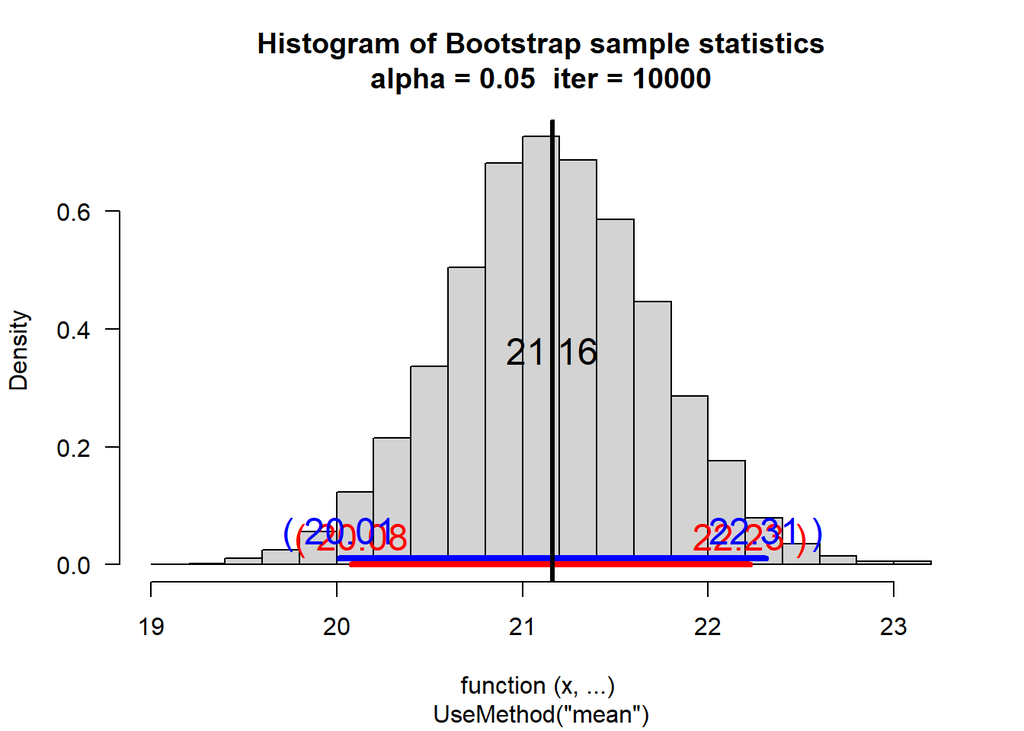

```r
myboot <- function(iter = 10000, x, fun = mean, alpha = 0.05, ...) {

  fun <- match.fun(fun)

  n <- length(x)

  y <- sample(x, n * iter, replace = TRUE)
  rs.mat <- matrix(y, nr = n, nc = iter, byrow = TRUE)

  xstat <- apply(rs.mat, 2, fun)

  ci <- quantile(xstat, c(alpha / 2, 1 - alpha / 2))

  xbar <- mean(x)
  s <- sd(x)
  error <- qt(1 - alpha / 2, df = n - 1) * s / sqrt(n)
  cit <- c(xbar - error, xbar + error)

  para <- hist(xstat, freq = FALSE, las = 1,
               main = paste("Histogram of Bootstrap sample statistics\nalpha =", alpha, " iter =", iter),
               xlab = deparse(substitute(fun)), ...)

  segments(ci[1], 0, ci[2], 0, col = "red", lwd = 4)
  text(ci[1], 0, paste("(", round(ci[1], 2)), col = "red", cex = 1.5, pos = 3)
  text(ci[2], 0, paste(round(ci[2], 2), ")"), col = "red", cex = 1.5, pos = 3)

  segments(cit[1], 0.01, cit[2], 0.01, col = "blue", lwd = 4)
  text(cit[1], 0.01, paste("(", round(cit[1], 2)), col = "blue", cex = 1.5, pos = 3)
  text(cit[2], 0.01, paste(round(cit[2], 2), ")"), col = "blue", cex = 1.5, pos = 3)

  pte <- fun(x)
  abline(v = pte, col = "black", lwd = 3)
  text(pte, max(para$density) / 2, round(pte, 2), cex = 1.5, col = "black")

  return(list(
    fun = deparse(substitute(fun)),
    x = x,
    t = qt(1 - alpha / 2, df = n - 1),
    ci = ci,
    cit = cit
  ))
}

result <- myboot(iter = 10000, x = sam, fun = mean, alpha = 0.05, col = "lightgray")
```

```r
print(result)
```

```
## $fun
## [1] "function (x, ...) "  "UseMethod(\"mean\")"
##
## $x
##  [1] 23.195 20.399 19.898 19.865 30.014 18.821 21.232 18.313 23.574 21.047
## [11] 21.535 21.336 17.695 18.497 14.274 14.664 22.593 18.963 25.515 25.019
## [21] 22.053 22.871 23.006 23.829 19.038 21.735 21.461 21.659 21.703 21.049
##
## $t
## [1] 2.04523
##
## $ci
##     2.5%    97.5%
## 20.07910 22.22545
##
## $cit
## [1] 20.01155 22.31198
```